# L13

```r
library(kernlab)
```

## Exercise 1

Use set.seed(20241128) to fix randomness. After that, form a 5-fold cross-validation data set (considering the full data set as training data). Then find the cross-validation accuracy of Random Forest method (used with default parameters) for predicting the class of AHD

```r
set.seed(20241128)
df = read_delim('Heart.csv', delim=',', col_select=-1)
cv_folds <- vfold_cv(df, v = 5)
```

```r
summary(df)
```

```
      Age             Sex          ChestPain             RestBP           Chol            Fbs            RestECG           MaxHR           ExAng           Oldpeak         Slope
 Min.   :29.00   Min.   :0.0000   Length:303         Min.   : 94.0   Min.   :126.0   Min.   :0.0000   Min.   :0.0000   Min.   : 71.0   Min.   :0.0000   Min.   :0.00   Min.   :1.000
 1st Qu.:48.00   1st Qu.:0.0000   Class :character   1st Qu.:120.0   1st Qu.:211.0   1st Qu.:0.0000   1st Qu.:0.0000   1st Qu.:133.5   1st Qu.:0.0000   1st Qu.:0.00   1st Qu.:1.000
 Median :56.00   Median :1.0000   Mode  :character   Median :130.0   Median :241.0   Median :0.0000   Median :1.0000   Median :153.0   Median :0.0000   Median :0.80   Median :2.000
 Mean   :54.44   Mean   :0.6799                      Mean   :131.7   Mean   :246.7   Mean   :0.1485   Mean   :0.9901   Mean   :149.6   Mean   :0.3267   Mean   :1.04   Mean   :1.601
 3rd Qu.:61.00   3rd Qu.:1.0000                      3rd Qu.:140.0   3rd Qu.:275.0   3rd Qu.:0.0000   3rd Qu.:2.0000   3rd Qu.:166.0   3rd Qu.:1.0000   3rd Qu.:1.60   3rd Qu.:2.000
 Max.   :77.00   Max.   :1.0000                      Max.   :200.0   Max.   :564.0   Max.   :1.0000   Max.   :2.0000   Max.   :202.0   Max.   :1.0000   Max.   :6.20   Max.   :3.000

       Ca             Thal               AHD
 Min.   :0.0000   Length:303         Length:303
 1st Qu.:0.0000   Class :character   Class :character
 Median :0.0000   Mode  :character   Mode  :character
 Mean   :0.6722
 3rd Qu.:1.0000
 Max.   :3.0000
 NA's   :4
```

```r
table(df$Thal, useNA='always')
```

```
     fixed     normal reversable       <NA>
        18        166        117          2
```

Filling missing values with means is dangerous practice because it may destroy some relations.

```r
rec1 = recipe(AHD~., data=df) |> step_impute_mean(Ca) |> step_impute_mode(Thal)

wf1=workflow() |> add_recipe(rec1) |>
  add_model(rand_forest(mode="classification"))

cv_results_rf <- wf1 |> fit_resamples(cv_folds)

collect_metrics(cv_results_rf)
```

| .metric | .estimator | mean | n | std_err | .config |
| --- | --- | --- | --- | --- | --- |
| accuracy | binary | 0.8118033 | 5 | 0.02785149 | Preprocessor1_Model1 |
| brier_class | binary | 0.1355338 | 5 | 0.01345513 | Preprocessor1_Model1 |
| roc_auc | binary | 0.9035038 | 5 | 0.01768817 | Preprocessor1_Model1 |

## Exercise 2

Add a variable setose with values Yes and No (according to the value of the Species variable) to iris dataset, name the modified dataset to ex1_data. Use tidymodels framework to fit SVM models to setosa using Sepal.Length and Petal.Length as predictors, using cost values 0.1,1,10 and produce corresponding classification plots with kernlab::plot(extract_fit_engine(model),data=ex1_data) command. What can you say about how cost parameter influences the number of support vectors?

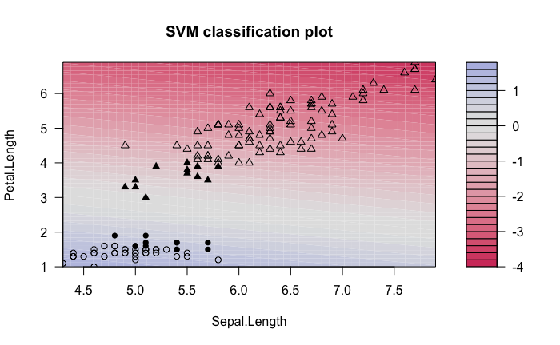

## Exercise 3

Use tuning to find the best linear support vector classifier for AHD in the case of Heart data both for unscaled and scaled predictors by using kernlab engine. Fit the best model to the full Heart data set and produce a graph with respect to variables Chol and MaxHR, which shows observations, actual value of AHD by shape and predicted value of AHD by color.

```r
# Create two recipes: one with scaling, one without
rec_unscaled <- rec1
rec_scaled <- rec1

# Define the SVM model with tunable cost
svm_model_scaled <- svm_linear(
  mode = "classification",
  engine = "kernlab",
  cost = tune(),

)

svm_model_unscaled <- svm_linear(
  mode = "classification",
  cost = tune(),
) |> set_engine("kernlab", scaled=FALSE)

# Set up workflows for unscaled and scaled predictors
wf_unscaled <- workflow() |>
  add_recipe(rec_unscaled) |>
  add_model(svm_model_unscaled)

wf_scaled <- workflow() |>
  add_recipe(rec_scaled) |>
  add_model(svm_model_scaled)

cost_grid <- data.frame(cost=10^seq(-3,3, length.out=5))

tuned_unscaled <- tune_grid(
  wf_unscaled,
  resamples = cv_folds,
  grid = cost_grid,
  metrics = metric_set(accuracy)
)

# Tune the model for scaled predictors
tuned_scaled <- tune_grid(
  wf_scaled,
  resamples = cv_folds,
  grid = cost_grid,
  metrics = metric_set(accuracy)
)

# Select the best hyperparameters for each case
show_best(tuned_unscaled, metric="accuracy")
```

| cost | .metric | .estimator | mean | n | std_err | .config |
| --- | --- | --- | --- | --- | --- | --- |
| 1.000000e+00 | accuracy | binary | 0.8151913 | 5 | 0.02766622 | Preprocessor1_Model3 |
| 3.162278e+01 | accuracy | binary | 0.8151366 | 5 | 0.02406290 | Preprocessor1_Model4 |
| 3.162278e-02 | accuracy | binary | 0.8085246 | 5 | 0.03058931 | Preprocessor1_Model2 |
| 1.000000e+03 | accuracy | binary | 0.7951913 | 5 | 0.03419665 | Preprocessor1_Model5 |
| 1.000000e-03 | accuracy | binary | 0.7129508 | 5 | 0.04158912 | Preprocessor1_Model1 |

```r
best_unscaled <- select_best(tuned_unscaled, metric="accuracy")

show_best(tuned_scaled, metric="accuracy")
```

| cost | .metric | .estimator | mean | n | std_err | .config |
| --- | --- | --- | --- | --- | --- | --- |
| 3.162278e-02 | accuracy | binary | 0.8185246 | 5 | 0.02584336 | Preprocessor1_Model2 |
| 1.000000e+00 | accuracy | binary | 0.8151913 | 5 | 0.02557946 | Preprocessor1_Model3 |
| 3.162278e+01 | accuracy | binary | 0.8151366 | 5 | 0.02720790 | Preprocessor1_Model4 |
| 1.000000e+03 | accuracy | binary | 0.8151366 | 5 | 0.02720790 | Preprocessor1_Model5 |
| 1.000000e-03 | accuracy | binary | 0.6213661 | 5 | 0.05888016 | Preprocessor1_Model1 |

```r
best_scaled <- select_best(tuned_scaled, metric="accuracy")

# Fit the best models to the full dataset
final_model_unscaled <- finalize_workflow(wf_unscaled, best_unscaled) |> fit(df)
final_model_scaled <- finalize_workflow(wf_scaled, best_scaled) |> fit(df)
# Add predictions to the dataset for visualization
df_predictions <- df |>
  mutate(
    Predicted_AHD = predict(final_model_scaled, new_data = df)$.pred_class
  )
```

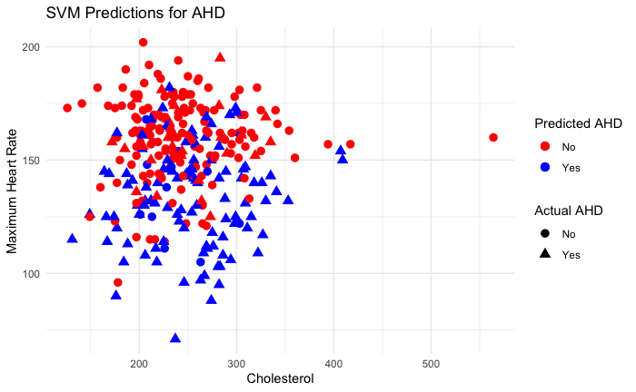

## Exercise 4

Divide the Heart dataset to training (70%) and validation sets by stratifying with respect ot AHD. Find the best linear linear SVM classifier for AHD in terms of Chol and MaxHR and produce plots about it’s performance on the training and validation sets.

```r
splitted = mc_cv(df, prop=0.7, strata=AHD, times=1)
train = training(splitted$splits[[1]])
validation = testing(splitted$splits[[1]])
```

```r
rec4 = recipe(AHD~Chol+MaxHR, data=train)
# Define the SVM model with tunable cost
svm_model_scaled <- svm_linear(
  mode = "classification",
  engine = "kernlab",
  cost = tune(),
)

wf4 <- workflow() |>
  add_recipe(rec4) |>
  add_model(svm_model_scaled)

cost_grid <- data.frame(cost=10^seq(-3,3, length.out=10))

tuned_4 <- tune_grid(
  wf4,
  resamples = splitted,
  grid = cost_grid,
  metrics = metric_set(accuracy)
)

show_best(tuned_4, metric="accuracy")
```

| cost | .metric | .estimator | mean | n | std_err | .config |
| --- | --- | --- | --- | --- | --- | --- |
| 0.1000000 | accuracy | binary | 0.7282609 | 1 | NA | Preprocessor1_Model04 |
| 0.4641589 | accuracy | binary | 0.7282609 | 1 | NA | Preprocessor1_Model05 |
| 2.1544347 | accuracy | binary | 0.7173913 | 1 | NA | Preprocessor1_Model06 |
| 10.0000000 | accuracy | binary | 0.7173913 | 1 | NA | Preprocessor1_Model07 |
| 46.4158883 | accuracy | binary | 0.7173913 | 1 | NA | Preprocessor1_Model08 |

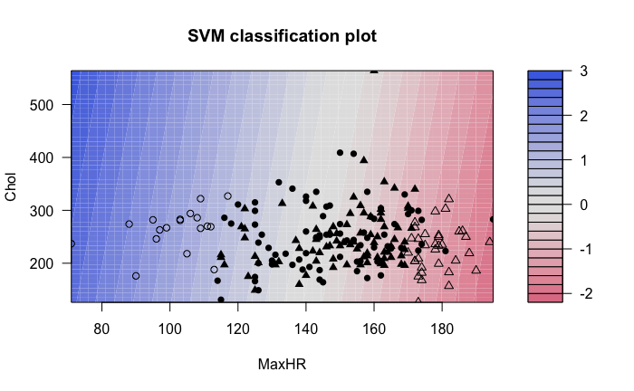

```r
m4 = wf4 |> finalize_workflow(select_best(tuned_4)) |> fit(train)
plot(extract_fit_engine(m4), data=train)
```

```r
NA
NA
```

## Exercise 5

Consider the same classification problem as in Exercise 4. Find by cross-validation the best cost parameter (allowing ksvm to choose itself kernel scale and offset) in the case polynomial kernel with degree 2. What is the best value of accuracy on the validation set? Produce plots about the best model’s performance on the training and validation sets. What scale and offset were used? Look at what happens when scale is changed (try values 0.1 and 10)